# STAT6014 Lecture 1

Jason Chan

2/2/2020

# Analyzing Challenger Data

## EDA

```r
ca <-data.frame("Temp"=c(53,56,57,63,66,67,67,67,68,69,70,70,
70,70,72,73,75,75,76,76,78,79,80,81),
"Failure"=c(rep(1,3),rep(0,8),rep(1,3),rep(0,3),
1,rep(0,6)))

summary(ca)
```

```
##       Temp          Failure
##  Min.   :53.00   Min.   :0.0000
##  1st Qu.:67.00   1st Qu.:0.0000
##  Median :70.00   Median :0.0000
##  Mean   :69.92   Mean   :0.2917
##  3rd Qu.:75.25   3rd Qu.:1.0000
##  Max.   :81.00   Max.   :1.0000
```

```r
ca
```

```
##    Temp Failure
## 1    53       1
## 2    56       1
## 3    57       1
## 4    63       0
## 5    66       0
## 6    67       0
## 7    67       0
## 8    67       0
## 9    68       0
## 10   69       0
## 11   70       0
## 12   70       1
## 13   70       1
## 14   70       1
## 15   72       0
## 16   73       0
## 17   75       0
## 18   75       1
## 19   76       0
## 20   76       0
## 21   78       0
## 22   79       0
## 23   80       0
## 24   81       0
```

```r
table(ca$Failure)
```

```
##
##  0  1
## 17  7
```

A lot more 0’s than 1’s, imbalanced.

## Modelling using Logistric Regression

```r
# using glm2 function

fit <- glm2(formula = Failure~Temp, family = "binomial", data = ca)
summary(fit)
```

```
##
## Call:
## glm2(formula = Failure ~ Temp, family = "binomial", data = ca)
##
## Deviance Residuals:
##     Min       1Q   Median       3Q      Max
## -1.2125  -0.8253  -0.4706   0.5907   2.0512
##
## Coefficients:
##             Estimate Std. Error z value Pr(>|z|)
## (Intercept) 10.87535    5.70291   1.907   0.0565 .
## Temp        -0.17132    0.08344  -2.053   0.0400 *
## ---
## Signif. codes:  0 '***' 0.001 '**' 0.01 '*' 0.05 '.' 0.1 ' ' 1
##
## (Dispersion parameter for binomial family taken to be 1)
##
##     Null deviance: 28.975  on 23  degrees of freedom
## Residual deviance: 23.030  on 22  degrees of freedom
## AIC: 27.03
##
## Number of Fisher Scoring iterations: 4
```

- This implies that $\beta_0 = 10.87535$ and $\beta_1 = -0.17132$
- This means that the fitted model is $logit(\pi) = 10.87535-0.17132x$
- And the estimated probability $\pi_i = e^{10.87535 -0.17132x} / (1+e^{10.87535 -0.17132x})$

## Prediction

```r
plotdata<-data.frame(Temp = seq(50,85,0.1))
predicted <-predict(fit, newdata= plotdata, type = "response")
```

## Probability Plot

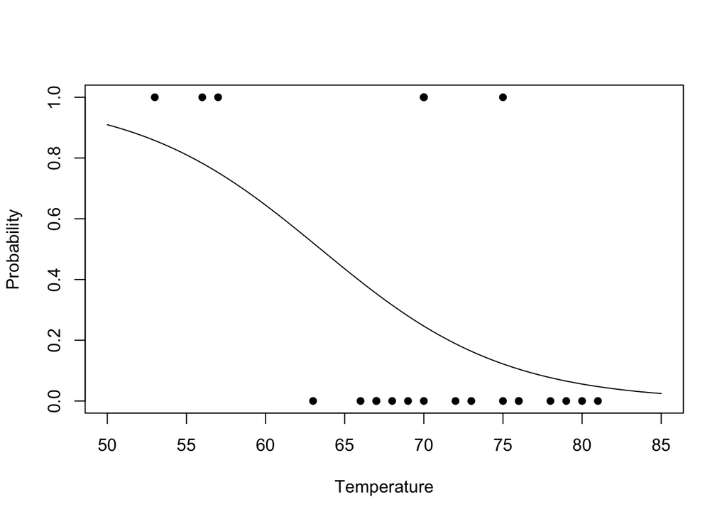

```r
plot(ca$Temp, ca$Failure, pch= 16, xlim= c(50,85), xlab= "Temperature", ylab= "Probability")
lines(plotdata$Temp, predicted)
```

Probality of break at Temp=50 Farenheit

```r
predict(fit, newdata= data.frame(Temp = c(50)), type = "response")
```

```
##         1
## 0.9096463
```

## Interpreting the Parameters (Beta)

```r
cbind(OR=coef(fit), confint(fit))
```

```
##                     OR      2.5 %     97.5 %
## (Intercept) 10.8753491  1.1941770 24.9888102
## Temp        -0.1713205 -0.3779407 -0.0305637
```

Need to exponential it to get the odds ratio

```r
exp(cbind(OR=coef(fit), confint(fit)))
```

```
##                       OR     2.5 %       97.5 %
## (Intercept) 5.285720e+04 3.3008401 7.120367e+10
## Temp        8.425515e-01 0.6852711 9.698986e-01
```

Since the **odds ratio (OR)** of Temp is 0.843 < 1, Temp is associated with a decrease in odds of 16% for an increase of 1 unit in Temp.

```r
1 - 8.425515e-01
```

```
## [1] 0.1574485
```

For an increase in 5F in Temp, would result in odd reduction of

```r
1 - exp(5*-0.1713205)
```

```
## [1] 0.5753978
```

# Analyzing Neuralgia Patients Data

## EDA

```r
# Create dataframe for Neuralgia Patients data
npd <- data.frame("Trt"=c('A','B','P'),
                  "Pain"=c(4,5,15),
                  "NoPain"=c(16,15,5))

# set reference class of Trt to 'P' for reference coding
npd$Trt <- relevel(npd$Trt, ref='P')

npd
```

```
##   Trt Pain NoPain
## 1   A    4     16
## 2   B    5     15
## 3   P   15      5
```

## Modelling

Note that data above is aggregated and will use a different syntax for model fitting as below:

```r
fit <- glm2(cbind(Pain, NoPain) ~ Trt, family = 'binomial', data=npd)
summary(fit)
```

```
##
## Call:
## glm2(formula = cbind(Pain, NoPain) ~ Trt, family = "binomial",
##     data = npd)
##
## Deviance Residuals:
## [1]  0  0  0
##
## Coefficients:
##             Estimate Std. Error z value Pr(>|z|)
## (Intercept)   1.0986     0.5164   2.127  0.03338 *
## TrtA         -2.4849     0.7610  -3.265  0.00109 **
## TrtB         -2.1972     0.7303  -3.009  0.00262 **
## ---
## Signif. codes:  0 '***' 0.001 '**' 0.01 '*' 0.05 '.' 0.1 ' ' 1
##
## (Dispersion parameter for binomial family taken to be 1)
##
##     Null deviance: 1.5758e+01  on 2  degrees of freedom
## Residual deviance: 1.7764e-15  on 0  degrees of freedom
## AIC: 15.436
##
## Number of Fisher Scoring iterations: 3
```

- Hence, the fitted model is $logit(\pi_x)=1.0986 - 2.4849I_A - 2.1972I_B$
- The logits for each treatment are:
  - Treatment A: $logit(\pi_A)=1.0986 - 2.4849I_A=-1.3863$
  - Treatment B: $logit(\pi_B)=1.0986 - 2.1972I_B=-1.0986$
  - Placebo: $logit(\pi_P)=1.0986$

Their probabilities of Pain are:

```r
prob_func <- function(x){
  return(exp(x)/(1+exp(x)))
}

prob_func(c(-1.3863, -1.0986, 1.0986))
```

```
## [1] 0.1999991 0.2500023 0.7499977
```

Placebo still gives high prob of pain compared to treatment A and B

Odds ratio of A to B:

```r
exp(-2.4849 - (-2.1972))
```

```
## [1] 0.7499866
```

Hence, a 25% reduction in odds of pain by treatment A compared to B.

Odds Reduction:

```r
exp(cbind(OR=coef(fit), confint(fit)))
```

```
##                     OR      2.5 %    97.5 %
## (Intercept) 3.00000000 1.16234573 9.2245900
## TrtA        0.08333333 0.01653094 0.3398993
## TrtB        0.11111111 0.02395103 0.4335703
```

Obviously Treatment A has the highest reduction in odds.